# Project overview

In this lesson, you’ll get an overview of the project we’ll build, its mechanics, and its code structure.

## The tower defense’s gameplay

In the tower defense we are building, the player goes through two phases:

1. In the planning phase, they purchase, place, and upgrade towers.
2. In the fighting phase, a wave of monsters walks along the level’s main path towards the player’s base.

The idea was to give the game a slight puzzle-like feel, even though I didn’t get to push that aspect as far as I’d like with the scope of this tutorial series.

In the planning phase, an interface appears at the bottom of the screen, allowing the player to click to select a tower. They then click an available space on the map to buy and place the tower.

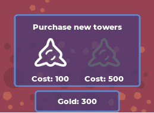

They can also click an existing tower to display an interface where they can upgrade or sell it.

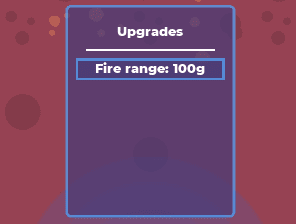

When the player clicks on the start button at the bottom, they move to the fighting phase.

In the fighting phase, monsters spawn in a queue and start to walk towards the player’s base.

When they get in range of the towers, the towers start shooting at them.

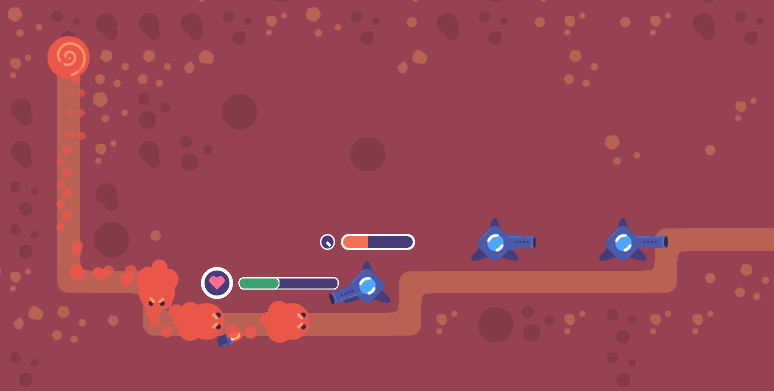

The player’s goal is to kill every monster in a wave with what they bought during the previous phase.

They have to balance buying towers and upgrades with limited resources, and they have to place towers in the most efficient location.

If too many enemies reach the player’s base, they destroy it, resulting in a game over.

On top of this gameplay loop, the final demo has animated dialogue boxes and supports playing animations to tell a little story.

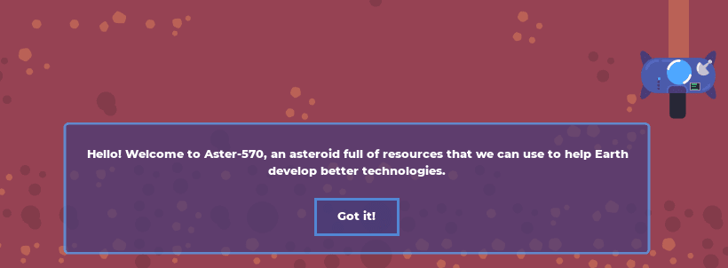

That’s the gist of the gameplay you’ll get to code create.

Let’s now see the code structure we will use to implement all these mechanics.

## Code structure

Here’s a high-level diagram of the overall code structure towards which we’ll work. It doesn’t show all the game systems; we’ll break it down below.

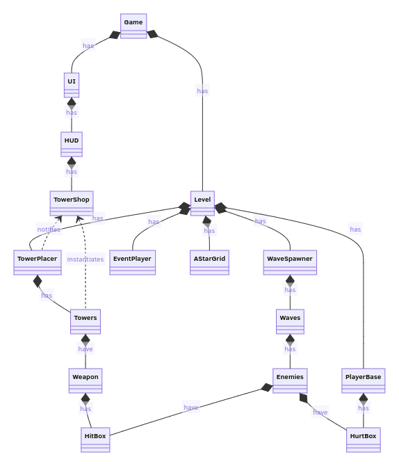

The black diamonds represent a composition relationship, which we tend to use a lot in Godot.

In short, we’ll have a main game node with two big node branches: one for the user interface (*UI* above) and one for the game level (*Level* in the diagram). They communicate indirectly through the *Game* node, using signal connections.

This helps to separate concerns. With this setup, we can modify the user interface anytime without breaking anything in the game level, and vice-versa.

It’s a setup we commonly use in 2D Secrets.

### Zooming on the user interface

Next, let’s take a closer look at the user interface’s code structure.

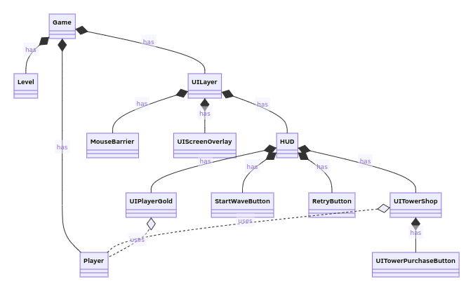

The *HUD* (Heads-Up Display) displays the player’s resources and buttons they can interact with. The *TowerShop* is the interface that allows the player to buy towers.

The *HUD* lives in the *UILayer*, a

[figure not shown]

`CanvasLayer`. That way, the UI always displays above the game world.

You can see a connection between the player and some parts of the interface. These interfaces need information about the player, and in this project, we judged it was fine to give the interface direct access to it.

### The structure of game levels

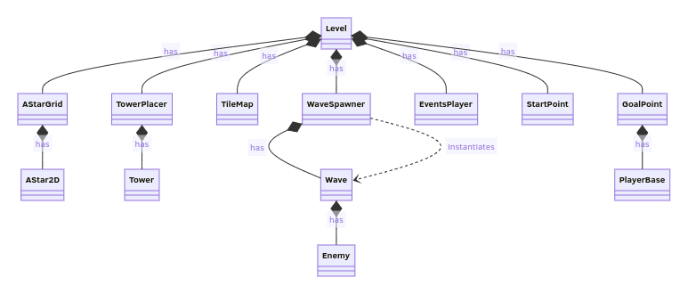

You can see the *Level* has a bunch of components to make the game work.

*AstarGrid*, *StartPoint*, and *GoalPoint* all handle pathfinding for the enemies. They allow you to draw any walkable path on the map and make the enemies find their way to the player’s base.

The *TowerPlacer* handles tower placement. It prevents players from placing towers on uneven terrains or places that other towers already occupy.

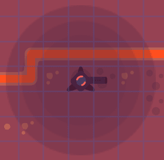

The *EventsPlayer* is a tool to sequence events, like displaying some text box, playing an animation, or spawning enemies.

It will show you how you can code a flexible system to do that, with only a few lines of code, using Godot’s animation system.

As an example, one of the main event types we create is the spawning of enemies. It relies on the *WaveSpawner*, which spawns a *Wave*.

A *Wave* lists enemies that spawn at given time intervals, one after the other. It also controls the path enemies will take to reach their goal.

### Hit and hurt boxes

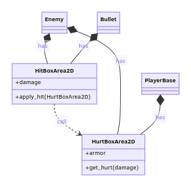

To deal and receive damage, our game entities make use of areas as hitboxes and hurt boxes.

The *HitBoxArea2D* detects when it overlaps with a *HurtBoxArea2D* and deals damage to it. The *HurtBoxArea2D* reacts to *HitBoxArea2Ds*’s damage, processes it, and notifies how much damage it took.

Entities like *Enemies* use both *HitBoxArea2D* and *HurtBoxArea2D*, as they deal and receive damage.

Like the *PlayerBase*, other elements only receive damage, so it only has a *HurtBoxArea2D*. And *Bullet_s only deal damage with a _HitBoxArea2D*.

In the next lesson, we’ll get started coding with this hit and hurt system.